# A study on the body language behaviours of UoA students

Hello anyone reading this, I wanted to study human body language and behaviour between individuals in Uoa. To do so, i collected data on people i spoke to on a daily basis, noting down their gender, responses to my eyebrow flashes as well as their Gesturical Hemispheric Tendencies. In the case of my studies, GHT means which side they tend to use when speaking or thinking of something positively.

## Eyebrow flash frequency by gender

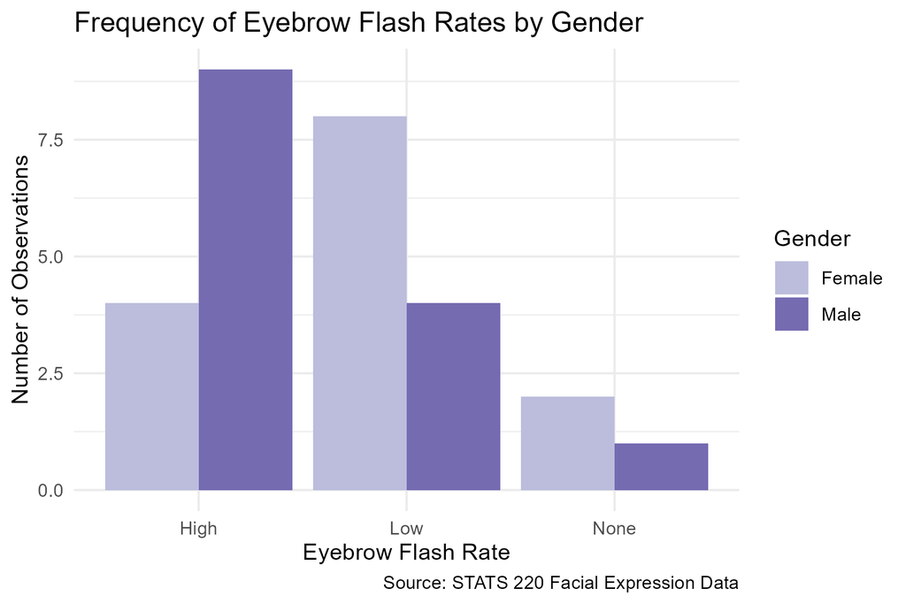

Plot of Gender versus eyebrow flash rate

In this bar graph, you can see the distribution of high, low and no eyebrow flash rates between male and female students.

It is clear that males tend to have higher eyebrow flash rates as compared to females. I wonder if this is because im a tall dude , so women are less comfortable around me? as compared to males at least.

## Eyebrow flash responses based on time of day

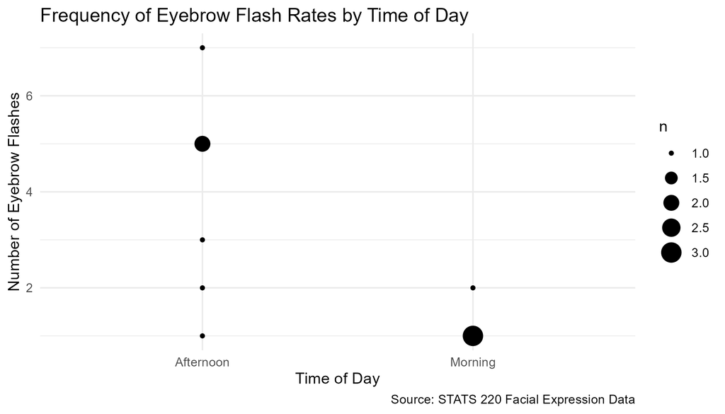

Plot of eyebrow flash frequency versus time of day

in this count plot, you can see the number of observations at a certain number of eyebrow flashes divided into afternoon and morning.

This tells me that people are less happy in the morning HAHAHAHA that totally makes sense.

## GHT by gender

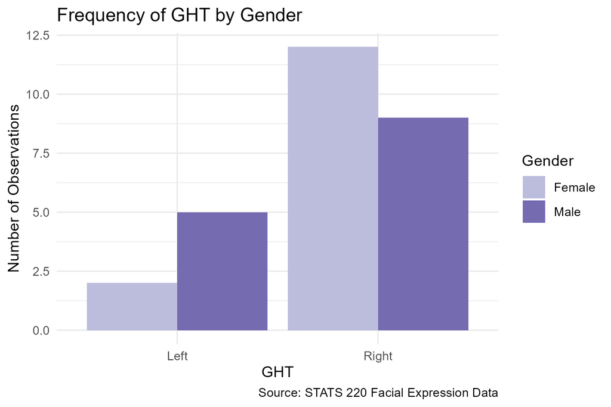

Bar graph of GHT based on gender

in my last visualisation, you are able to see the distribution of left and right GHT based on gender.